# A3-Componentes Principales

Esteban Sierra

2025-10-14

## Parte 0: Análisis Descriptivo

```r
D = read.csv("C:/Users/Pansocrates03/Documents/7mo Semestre/ESTADISTICA/corporal.csv")
```

```r
summary(D)
```

```
##       edad            peso           altura          sexo
##  Min.   :19.00   Min.   :42.00   Min.   :147.2   Length:36
##  1st Qu.:24.75   1st Qu.:54.95   1st Qu.:164.8   Class :character
##  Median :28.00   Median :71.50   Median :172.7   Mode  :character
##  Mean   :31.44   Mean   :68.95   Mean   :171.6
##  3rd Qu.:37.00   3rd Qu.:82.40   3rd Qu.:179.4
##  Max.   :65.00   Max.   :98.20   Max.   :190.5
##      muneca           biceps
##  Min.   : 8.300   Min.   :23.50
##  1st Qu.: 9.475   1st Qu.:25.98
##  Median :10.650   Median :32.15
##  Mean   :10.467   Mean   :31.17
##  3rd Qu.:11.500   3rd Qu.:35.05
##  Max.   :12.400   Max.   :40.40
```

Correlación en las variables numéricas

```r
D_numericos = D[, sapply(D, is.numeric)]
cor(D_numericos)
```

```
##             edad      peso    altura    muneca    biceps
## edad   1.0000000 0.5153847 0.3302211 0.6204942 0.4836702
## peso   0.5153847 1.0000000 0.7973737 0.8493361 0.9088813
## altura 0.3302211 0.7973737 1.0000000 0.6595849 0.7086144
## muneca 0.6204942 0.8493361 0.6595849 1.0000000 0.8777369
## biceps 0.4836702 0.9088813 0.7086144 0.8777369 1.0000000
```

## PARTE 1

Realiza el análisis de los valores y vectores propios con la matriz de covarianzas y con la de correlación. Analiza la varianza explicada por cada componente en cada caso e interpreta dentro del contexto del problema.

### Calcule las matrices de varianza-covarianza S con cov(X) y la matriz de correlaciones R con cor(X) y realice los siguientes pasos con cada una:

```r
#Matriz de varianza covarianza
cat("Covarianza de las variables\n")
```

```
## Covarianza de las variables
```

```r
covarianza = cov(D_numericos)
covarianza
```

```
##              edad      peso     altura    muneca    biceps
## edad   111.396825  80.88159  36.666032  7.698095 26.720952
## peso    80.881587 221.08713 124.728698 14.844667 70.738381
## altura  36.666032 124.72870 110.673968  8.156476 39.021048
## muneca   7.698095  14.84467   8.156476  1.381714  5.400571
## biceps  26.720952  70.73838  39.021048  5.400571 27.398857
```

```r
cat("\nCorrelación entre las variables\n")
```

```
##
## Correlación entre las variables
```

```r
correlacion = cor(D_numericos)
correlacion
```

```
##             edad      peso    altura    muneca    biceps
## edad   1.0000000 0.5153847 0.3302211 0.6204942 0.4836702
## peso   0.5153847 1.0000000 0.7973737 0.8493361 0.9088813
## altura 0.3302211 0.7973737 1.0000000 0.6595849 0.7086144
## muneca 0.6204942 0.8493361 0.6595849 1.0000000 0.8777369
## biceps 0.4836702 0.9088813 0.7086144 0.8777369 1.0000000
```

#### 1.1 Valores y Vectores de cada matriz.

```r
cat("Valores y vectores propios de la matriz de covarianza\n")
```

```
## Valores y vectores propios de la matriz de covarianza
```

```r
vectores_covarianza = eigen(covarianza)
vectores_covarianza
```

```
## eigen() decomposition
## $values
## [1] 359.3980243  80.3757858  27.6229011   4.3074318   0.2343571
##
## $vectors
##             [,1]       [,2]        [,3]         [,4]         [,5]
## [1,] -0.34871002  0.9075501 -0.23248825 -0.001589466  0.026473941
## [2,] -0.76617586 -0.1616581  0.52166894 -0.338508602  0.010707863
## [3,] -0.47632405 -0.3851755 -0.78905759  0.046160807  0.003543154
## [4,] -0.05386189  0.0155423  0.02785902  0.126103480 -0.990039959
## [5,] -0.24817367 -0.0402221  0.22455005  0.931330496  0.137814357
```

```r
cat("\nValores y vectores de la matriz de correlación\n")
```

```
##
## Valores y vectores de la matriz de correlación
```

```r
vectores_correlacion = eigen(correlacion)
vectores_correlacion
```

```
## eigen() decomposition
## $values
## [1] 3.75749733 0.72585665 0.32032981 0.12461873 0.07169749
##
## $vectors
##            [,1]       [,2]        [,3]       [,4]       [,5]
## [1,] -0.3359310  0.8575601 -0.34913780 -0.1360111  0.1065123
## [2,] -0.4927066 -0.1647821  0.06924561 -0.5249533 -0.6706087
## [3,] -0.4222426 -0.4542223 -0.73394453  0.2070673  0.1839617
## [4,] -0.4821923  0.1082775  0.36690716  0.7551547 -0.2255818
## [5,] -0.4833139 -0.1392684  0.44722747 -0.3046138  0.6739511
```

#### 1.2 Proporción de varianza

*Calcule la proporción de varianza explicada por cada componente en ambas matrices. Se sugiere dividir cada lambda entre la varianza total (las lambdas están en eigen(S)$values). La varianza total es la suma de las varianzas de la diagonal de S. Una forma es sum(diag(S)). La varianza total de los componentes es la suma de los valores propios (es decir, la suma de la varianza de cada componente), sin embargo, si sumas la diagonal de S (es decir, la varianza de cada x), te da el mismo valor (¡comprúebalo!). Recuerda que las combinaciones lineales buscan reproducir la varianza de X.*

```r
cat("Proporción de varianza de la covarianza\n")
```

```
## Proporción de varianza de la covarianza
```

```r
lambda_covarianza = c(59.3980243,80.3757858 ,27.6229011,4.3074318,0.2343571)

varianza_total_covarianza = sum(lambda_covarianza)

proporcion_de_varianza_covarianza = lambda_covarianza / varianza_total_covarianza
proporcion_de_varianza_covarianza
```

[output not shown]

```r
cat("\nProporción de varianza de la correlación\n")
```

```
##
## Proporción de varianza de la correlación
```

```r
lambda_correlacion = c(3.75749733, 0.72585665, 0.32032981, 0.12461873, 0.07169749)
varianza_total_correlacion = sum(lambda_correlacion)
proporcion_de_varianza_correlacion = lambda_correlacion / varianza_total_correlacion
proporcion_de_varianza_correlacion
```

```
## [1] 0.75149946 0.14517133 0.06406596 0.02492375 0.01433950
```

#### 1.3 Acumule los resultados anteriores (cumsum() puede servirle) para obtener la varianza acumulada en cada componente.

```r
cat("Varianza acumulada de covarianza\n")
```

```
## Varianza acumulada de covarianza
```

```r
cumsum(proporcion_de_varianza_covarianza)
```

[output not shown]

```r
cat("\nVarianza acumulada de correlación\n")
```

```
##
## Varianza acumulada de correlación
```

```r
cumsum(proporcion_de_varianza_correlacion)
```

```
## [1] 0.7514995 0.8966708 0.9607368 0.9856605 1.0000000
```

#### 1.4 Según los resultados anteriores, ¿qué componentes son los más importantes?*

Así mismo, el componente más importante según la varianza de correlación es el primer componente, ya que tiene una proporción de 75%.

Los dos primeros componentes principales (CP1 y CP2) son los más importantes, ya que logran explicar casi el 90% de la variabilidad de tus datos.

#### 1.5 Escriba la ecuación de la combinación lineal de los Componentes principales CP1 y CP2 (eiX, donde ei está en eigen(S)$vectors[1], e2X para obtener CP2, donde X = c(X1, X2, …)) ¿qué variables son las que más contribuyen a la primera y segunda componentes principales? (observe los coeficientes en valor absoluto de las combinaciones lineales). Justifique su respuesta.

¡No te olvides de seguir los mismos pasos con la matriz de correlaciones (se obtiene con cor(x) si x está compuesto por variables numéricas)

Ecuación para CP1:

$CP1 = (−0.3487)Edad+(−0.7662)Peso+(−0.4763)Altura+(−0.0539)Muneca+(−0.2482)Biceps$

Ecuación para CP2:

$CP2=(0.9076)Edad+(−0.1617)Peso+(−0.3852)Altura+(0.0155)Muneca+(−0.0402)Biceps$

## Parte 2

### 1. Obtenga las gráficas respectivas con S (matriz de varianzas-covarianzas) y con R (matriz de correlaciones) de las dos primeras componentes.

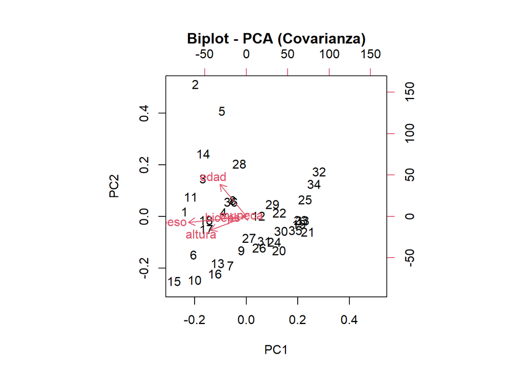

```r
# PCA con la matriz de covarianza (S)
pca_cov <- prcomp(D_numericos, scale = FALSE)

biplot(pca_cov, choices = 1:2, main = "Biplot - PCA (Covarianza)")
```

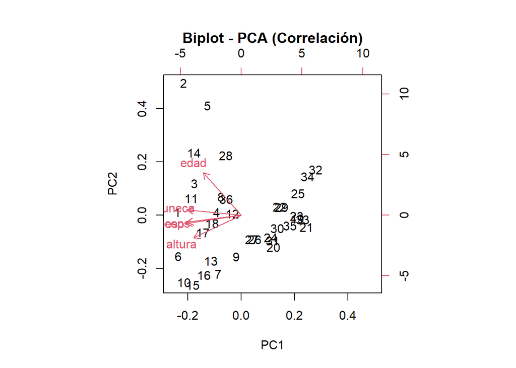

```r
# PCA con la matriz de correlacion
pca_cor <- prcomp(D_numericos, scale = TRUE)
biplot(pca_cor, choices = 1:2, main = "Biplot - PCA (Correlación)")
```

```r
cat("scores de la matriz de covarianzas\n")
```

```
## scores de la matriz de covarianzas
```

```r
summary(pca_cov)
```

```
## Importance of components:
##                            PC1    PC2     PC3     PC4    PC5
## Standard deviation     18.9578 8.9653 5.25575 2.07544 0.4841
## Proportion of Variance  0.7615 0.1703 0.05853 0.00913 0.0005
## Cumulative Proportion   0.7615 0.9318 0.99038 0.99950 1.0000
```

```r
cat("\nScores de la matriz de correlaciones\n")
```

```
##
## Scores de la matriz de correlaciones
```

```r
summary(pca_cor)
```

```
## Importance of components:
##                           PC1    PC2     PC3     PC4     PC5
## Standard deviation     1.9384 0.8520 0.56598 0.35301 0.26776
## Proportion of Variance 0.7515 0.1452 0.06407 0.02492 0.01434
## Cumulative Proportion  0.7515 0.8967 0.96074 0.98566 1.00000
```

### 2. Interprete los gráficos en términos de:

#### 2.1 Las relaciones que se establecen entre las variables y los componentes principales

#### 2.2 La relación entre las puntuaciones de las observaciones y los valores de las variables

#### 2.3 Detecte posibles datos atípicos

### 3. Explora el: princomp() en library(stats). Puedes poner help(princomp) en la consola o buscarlo en la ventana de ayuda. Indaga: ¿qué otras opciones tiene para facilitarte el análisis? En particular, explora los comandos y subcomandos: summary(cpS), cpaS$loading, cpaS$scores. ¿Cómo se interpreta el resultado?

Sugerencias en R

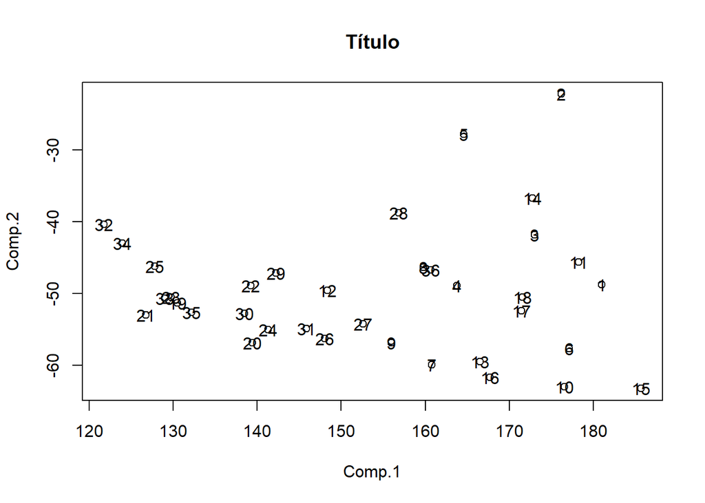

```r
library(stats)
datos=D_numericos
cpS=princomp(datos,cor=FALSE) #Para la matriz de correlación usa cor=TRUE
cpaS=as.matrix(datos)%*%cpS$loadings  #Calcula las puntuaciones
plot(cpaS[,1:2],type="p", main = "Título")
text(cpaS[,1],cpaS[,2],1:nrow(cpaS))
```

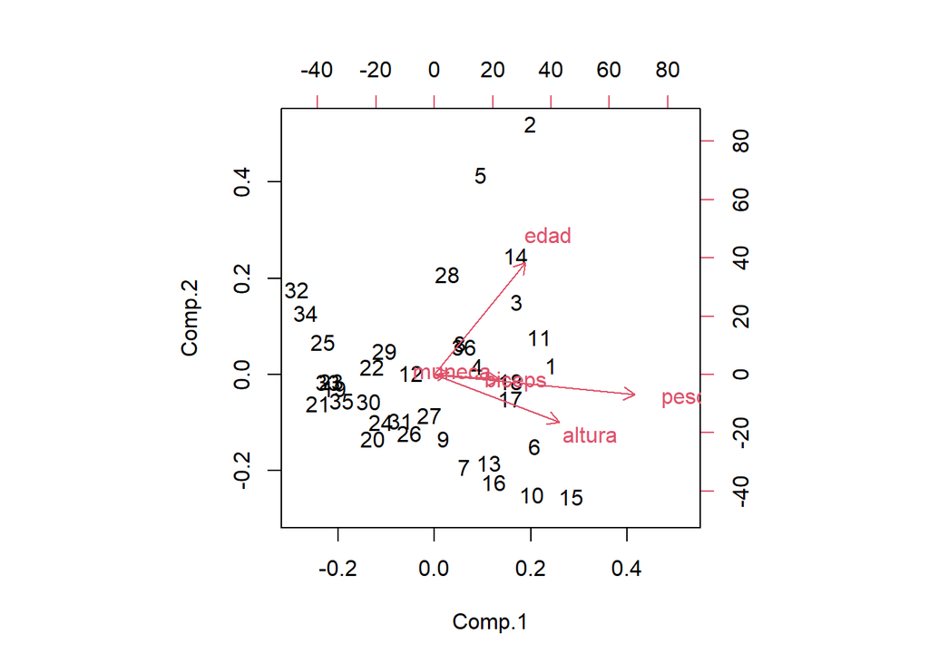

```r
biplot(cpS)
```

## Parte 3

### Interprete cada gráfico e identifica qué es lo que se está graficando en cada uno. Realiza el análisis con la matriz de varianzas y covarianzas y correlación.

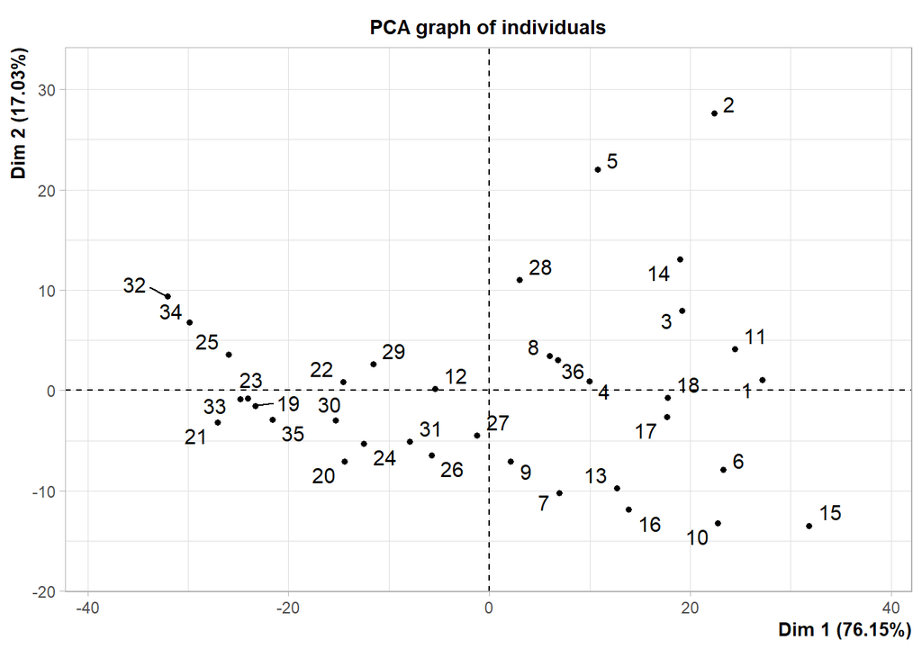

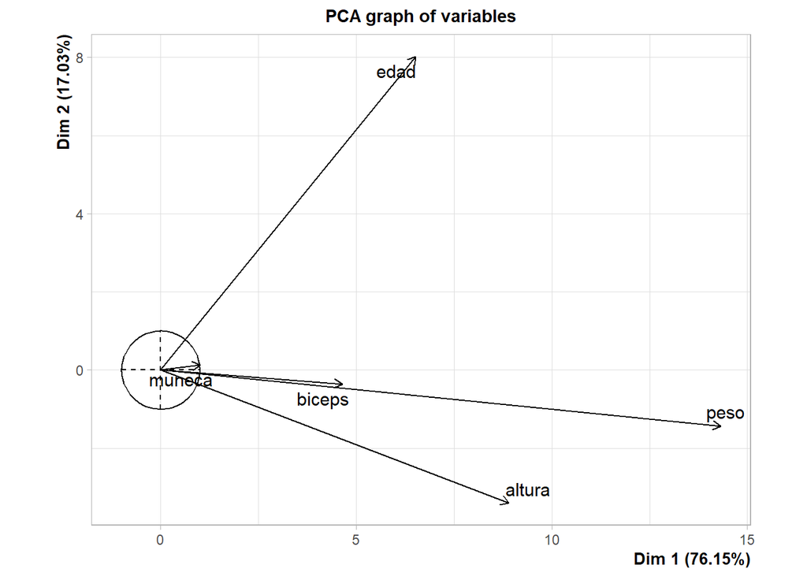

```r
library(FactoMineR)
library(ggplot2)
datos=D_numericos
cpS = PCA(datos,scale.unit=FALSE)
```

Estas dos gráficas muestran las gráficas y las variables donde cada variable (edad, peso, altura, etc.) se representa como un punto o un vector. Estos datos se pueden interpretar de varias formas. La distancia del punto al círculo de correlación indica qué tan bien la variable es representada por el plano CP1/CP2.Al mismo tiempo el ángulo entre los vectores indica la correlación entre las variables: ángulos pequeños (vectores en la misma dirección) significan correlación positiva, ángulos de 90∘ significan no correlación, y ángulos de 180∘ significan correlación negativa. En este caso no tenemos ninguna correlación negativa.

```r
library(factoextra)
```

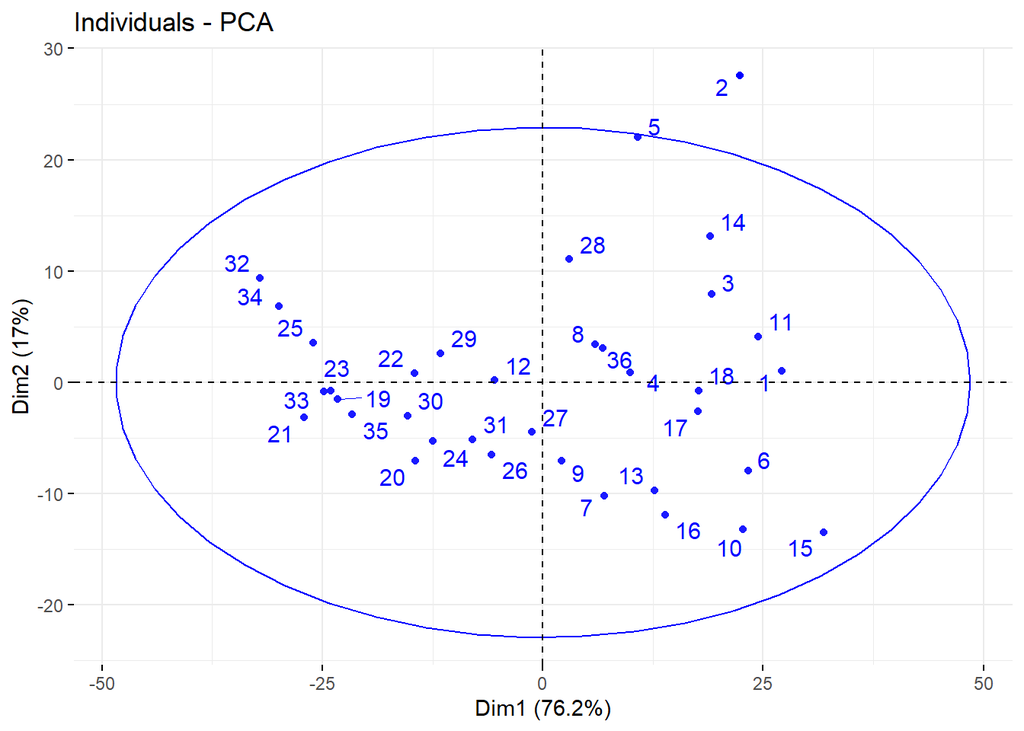

```r
fviz_pca_ind(cpS, col.ind = "blue", addEllipses = TRUE, repel = TRUE)
```

Este es un gráfico de dispersión centrado únicamente en la proyección de los individuos sobre el plano formado por las dos primeras Componentes Principales (CP1 y CP2), usando los resultados del PCA basado en la Covarianza

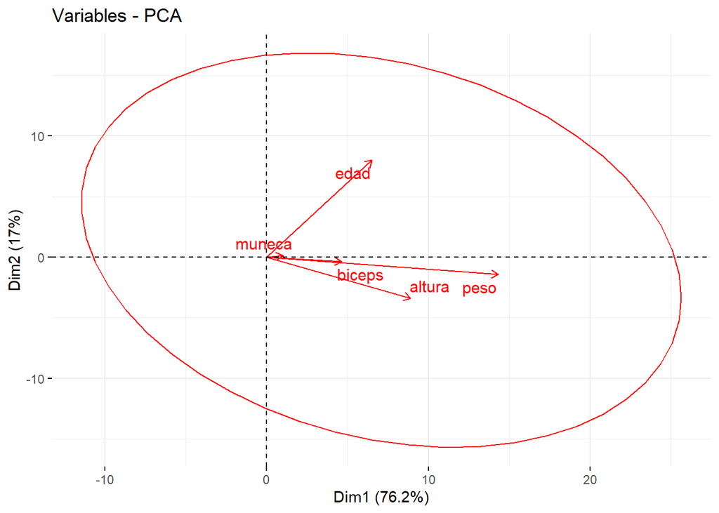

```r
fviz_pca_var(cpS, col.var = "red", addEllipses = TRUE, repel = TRUE)
```

Al igual que el gráfico anterior, este muestra el mismo plano pero a través de los vectores de las variables en lugar de los puntos individuales.

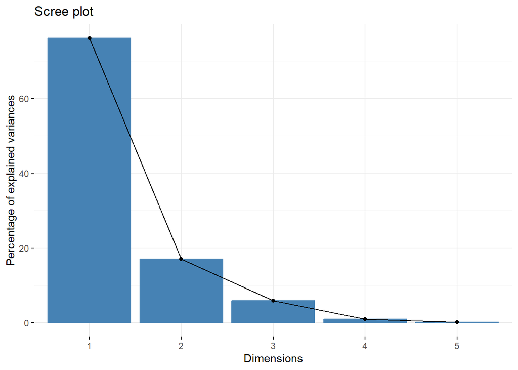

```r
fviz_screeplot(cpS)
```

Esta gráfica muestra el valor de los valores propios (eigenvalues) o el porcentaje de varianza explicado en el eje Y para cada Componente Principal consecutiva (CP1, CP2, CP3, etc.) en el eje X. Su propósito es demostrar la importancia relativa de cada componente

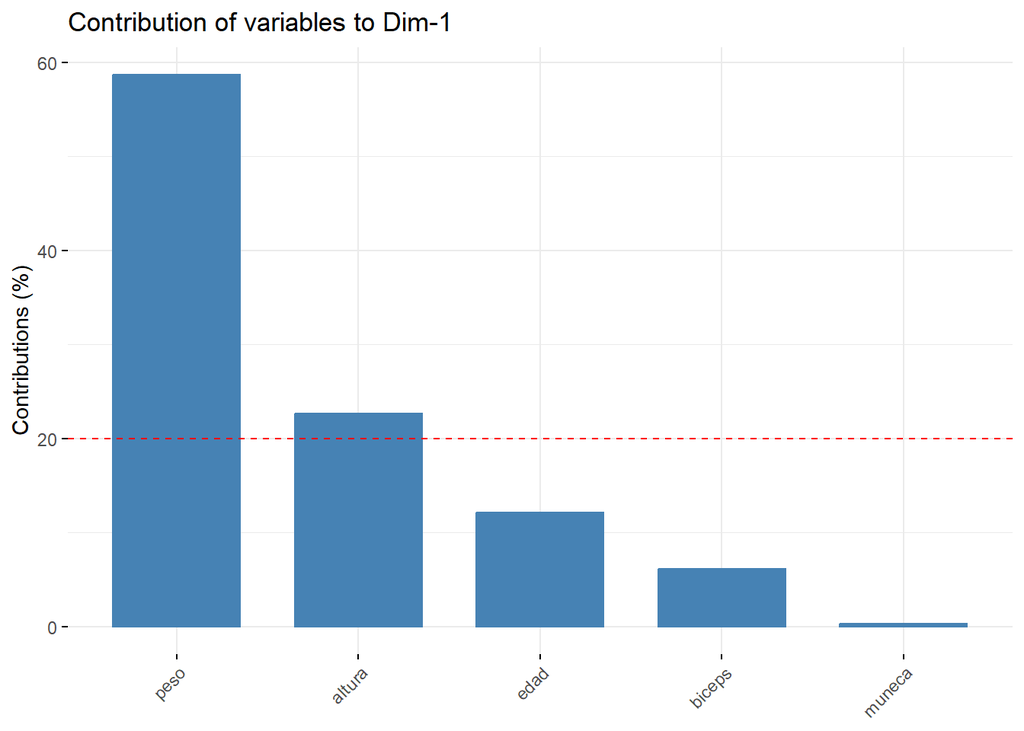

```r
fviz_contrib(cpS, choice = c("var"))
```

Este gráfico demuestra la contribución absoluta de las variables al primer componente

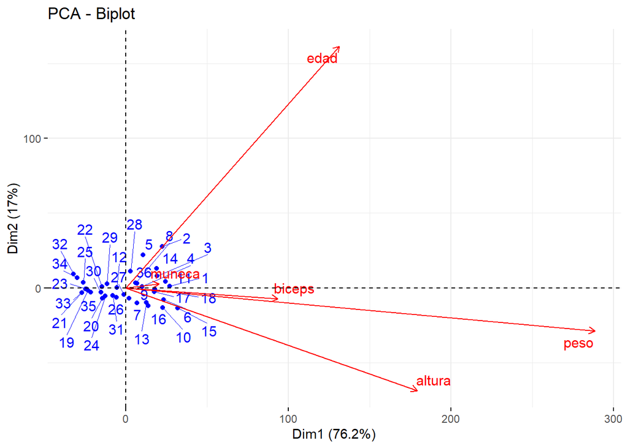

```r
fviz_pca_biplot(cpS, repel=TRUE, col.var="red", col.ind="blue")
```

demuestra simultáneamente la relación entre los individuos y las variables en el espacio de las dos primeras Componentes Principales (CP1 y CP2), usando los resultados del PCA de la matriz de Covarianza (cpS). Los puntos azules (col.ind=“blue”) muestran la posición de cada individuo, indicando si tienen valores altos o bajos en las variables que definen los componentes, mientras que las flechas rojas (col.var=“red”) representan las variables, permitiendo visualizar la correlación entre las variables y la influencia de las variables sobre los individuos. De esta forma, el gráfico permite interpretar en qué medida los individuos son descritos por ciertas variables (por ejemplo, los individuos en la dirección de la flecha de “peso” tienen un peso superior al promedio).

## Parte 4

Finalmente: Concluye sobre el análisis de componentes principales realizado e interprete los resultados.

### ¿Qué variables son las que más contribuyen a la primera y segunda componentes principales del método seleccionado? (observa los coeficientes en valor absoluto de las combinaciones lineales, auxíliate también de los gráficos)

El método seleccionado como mejor es el basado en la matriz de Correlación (R), ya que estandariza las variables y ofrece una interpretación más robusta. Observando los coeficientes de los vectores propios (las combinaciones lineales) y el biplot de la correlación: a la primera componente principal (CP1), la que explica el 75.15% de la varianza, contribuyen fuertemente las variables de Peso, Altura, Muñeca y Bíceps, lo que define a este componente como el factor de “Tamaño Corporal General”. Por su parte, la segunda componente principal (CP2), que explica el 14.52% de la varianza, está dominada casi por completo por la variable Edad, aislando la dimensión de la variabilidad relacionada con el envejecimiento.